# Assignment 3: Measuring Poverty in Philadelphia

- Show All Code
- Hide All Code
- View Source

Measuring uncertainty in American Community Survey data

Author

Emmanuel Sampson

Published

September 25, 2026

## Data and definition of poverty

How did poverty change across Philadelphia, and how much confidence can we place in those changes? This analysis compares estimates from the American Community Survey (ACS) for 2006–2010 and 2013–2017. It examines census tracts, small statistical areas that help describe conditions within the city. Each estimate represents a five-year period.

The poverty rate measures the percentage of people living below the poverty level among those whose poverty status is determined by the survey. For example, a rate of 25% means one in four people in that group lives below the poverty level. The data come from the Census Bureau’s [poverty-status table](https://api.census.gov/data/2017/acs/acs5/groups/B17001.html).

## Poverty rates and margins of error

The ACS surveys a sample of residents, so its estimates carry sampling uncertainty. A margin of error (MOE) describes that uncertainty: a larger MOE means a less precise estimate. A poverty rate of 25% with an MOE of 5 **percentage points** gives an approximate 90% confidence interval of 20%–30%. Across repeated samples, intervals calculated this way would contain the true value about 90% of the time.

The calculations account for uncertainty in both the number of people below the poverty level and the population used to calculate the rate, using the [proportion method documented by tidycensus](https://walker-data.com/tidycensus/articles/margins-of-error.html).

```r
calculate_rates <- function(data, period_label) {
  data %>%
    mutate(
      # Treat unavailable values and Census missing-data codes as missing.
      across(c(total_popE, total_popM, povertyE, povertyM),
             ~ replace(.x, !is.finite(.x) | .x < 0, NA_real_)),
      denominator = if_else(total_popE > 0 & !is.na(povertyE) &
                              povertyE <= total_popE, total_popE, NA_real_),
      poverty_rate = 100 * povertyE / denominator,
      poverty_rate_moe = 100 * moe_prop(
        povertyE, denominator, povertyM, total_popM
      ),
      lower_90 = pmax(0, poverty_rate - poverty_rate_moe),
      upper_90 = pmin(100, poverty_rate + poverty_rate_moe),
      period = period_label
    ) %>% select(-denominator)
}
poverty_2010 <- calculate_rates(poverty_2010, "2006-2010")
poverty_2017 <- calculate_rates(poverty_2017, "2013-2017")

poverty_2017 %>% st_drop_geometry() %>%
  select(GEOID, poverty_rate, poverty_rate_moe, lower_90, upper_90) %>%
  head(10) %>%
  knitr::kable(digits = 2,
               col.names = c("Tract ID", "Poverty rate (%)", "Margin of error (points)",
                             "90% lower bound (%)", "90% upper bound (%)"),
               caption = "Poverty estimates for ten tracts, 2013–2017")
```

Poverty estimates for ten tracts, 2013–2017

| Tract ID | Poverty rate (%) | Margin of error (points) | 90% lower bound (%) | 90% upper bound (%) |
| --- | --- | --- | --- | --- |
| 42101000200 | 37.61 | 13.39 | 24.22 | 51.00 |
| 42101000500 | 34.83 | 6.36 | 28.47 | 41.19 |
| 42101000901 | 24.27 | 6.34 | 17.93 | 30.61 |
| 42101001002 | 6.38 | 4.90 | 1.48 | 11.27 |
| 42101002000 | 16.95 | 6.21 | 10.73 | 23.16 |
| 42101003901 | 21.57 | 7.16 | 14.41 | 28.73 |
| 42101007102 | 34.69 | 11.19 | 23.50 | 45.88 |
| 42101008701 | 25.11 | 6.76 | 18.36 | 31.87 |
| 42101010200 | 40.38 | 12.89 | 27.49 | 53.27 |
| 42101011500 | 15.77 | 6.56 | 9.21 | 22.33 |

## Reliability of tract estimates

To compare precision across tracts, this analysis expresses each margin of error as a percentage of its estimated poverty rate. This **relative MOE** is smaller when the estimate is more precise. For example, an MOE of 5 percentage points around a rate of 25% gives a relative MOE of 20%.

This analysis labels relative MOEs below 12% as reliable, 12% to less than 40% as somewhat reliable, and 40% or above as unreliable. These thresholds are specific to this analysis. A relative margin of error cannot be calculated when the estimated poverty rate is zero, because that would require dividing by zero. These cases and missing data are listed separately.

```r
classify_reliability <- function(data) {
  data %>% mutate(
    moe_pct = 100 * poverty_rate_moe /
      if_else(poverty_rate > 0, poverty_rate, NA_real_),
    reliability = case_when(
      is.na(poverty_rate) | is.na(poverty_rate_moe) ~ "No valid estimate/MOE",
      poverty_rate == 0 ~ "Zero estimate: relative MOE undefined",
      moe_pct < 12 ~ "Reliable",
      moe_pct < 40 ~ "Somewhat reliable",
      TRUE ~ "Unreliable"
    )
  )
}
poverty_2010 <- classify_reliability(poverty_2010) %>% st_transform(4326)
poverty_2017 <- classify_reliability(poverty_2017) %>% st_transform(4326)
poverty_change <- bind_rows(poverty_2010, poverty_2017)

reliability_summary <- poverty_change %>% st_drop_geometry() %>%
  count(period, reliability, name = "tracts") %>%
  group_by(period) %>% mutate(percent = 100 * tracts / sum(tracts)) %>%
  ungroup()
knitr::kable(reliability_summary, digits = 1,
             col.names = c("Period", "Reliability", "Number of tracts", "Share of tracts (%)"),
             caption = "Reliability by period (including unavailable estimates)")
```

Reliability by period (including unavailable estimates)

| Period | Reliability | Number of tracts | Share of tracts (%) |
| --- | --- | --- | --- |
| 2006-2010 | No valid estimate/MOE | 7 | 1.8 |
| 2006-2010 | Somewhat reliable | 178 | 46.4 |
| 2006-2010 | Unreliable | 197 | 51.3 |
| 2006-2010 | Zero estimate: relative MOE undefined | 2 | 0.5 |
| 2013-2017 | No valid estimate/MOE | 8 | 2.1 |
| 2013-2017 | Reliable | 1 | 0.3 |
| 2013-2017 | Somewhat reliable | 232 | 60.4 |
| 2013-2017 | Unreliable | 143 | 37.2 |

Estimates labeled unreliable have large margins of error compared with the estimated rates. This makes it difficult to rank those tracts confidently by poverty rate. Even a modest margin of error can be large relative to a very low poverty rate.

## Change between periods

Tracts are matched across periods using their Census geographic identifiers (`GEOID`). The table below shows how many appear in both periods or only one. Comparisons assume the matched tracts represent comparable areas; matching identifiers alone does not verify that boundaries are identical. The Census Bureau documents the geographic definitions in its [ACS geography guidance](https://www.census.gov/programs-surveys/acs/geography-acs/geography-boundaries-by-year/2010.html).

```r
tract_data <- poverty_change %>% st_drop_geometry()
stopifnot(!anyDuplicated(tract_data[c("GEOID", "period")]))
coverage <- full_join(
  st_drop_geometry(poverty_2010) %>% transmute(GEOID, in_2010 = TRUE),
  st_drop_geometry(poverty_2017) %>% transmute(GEOID, in_2017 = TRUE),
  by = "GEOID"
) %>% mutate(coverage = case_when(
  is.na(in_2010) ~ "2017 only",
  is.na(in_2017) ~ "2010 only",
  TRUE ~ "Both periods"
))
knitr::kable(count(coverage, coverage, name = "tracts"),
             col.names = c("Data availability", "Number of tracts"))
```

| Data availability | Number of tracts |
| --- | --- |
| Both periods | 384 |

```r
poverty_wide <- tract_data %>%
  select(GEOID, period, poverty_rate, poverty_rate_moe) %>%
  pivot_wider(id_cols = GEOID, names_from = period,
              values_from = c(poverty_rate, poverty_rate_moe))
```

The change is the later poverty rate minus the earlier rate. For example, an increase from 20% to 25% is a rise of 5 percentage points. Assuming independent estimates for these non-overlapping periods, the change MOE is the square root of the sum of the squared MOEs. A change is significant at approximately the 90% level when its absolute value exceeds this MOE. Each tract is tested separately, without adjusting for the number of tests. With many tests, some changes may appear significant by chance. Failure to detect a change does not prove poverty stayed constant.

```r
poverty_wide <- poverty_wide %>% mutate(
  change_pp = `poverty_rate_2013-2017` - `poverty_rate_2006-2010`,
  change_moe = sqrt(`poverty_rate_moe_2013-2017`^2 +
                      `poverty_rate_moe_2006-2010`^2),
  change_lower_90 = change_pp - change_moe,
  change_upper_90 = change_pp + change_moe,
  change_result = case_when(
    is.na(change_pp) | is.na(change_moe) ~ "Not estimable",
    change_lower_90 > 0 ~ "Significant increase",
    change_upper_90 < 0 ~ "Significant decrease",
    TRUE ~ "No significant change"
  )
)
change_summary <- count(poverty_wide, change_result, name = "tracts")
knitr::kable(change_summary,
             col.names = c("Change assessment", "Number of tracts"),
             caption = "Tract changes at the 90% confidence level")
```

Tract changes at the 90% confidence level

| Change assessment | Number of tracts |
| --- | --- |
| No significant change | 313 |
| Not estimable | 8 |
| Significant decrease | 27 |
| Significant increase | 36 |

```r
poverty_wide %>% filter(!is.na(change_moe), !is.na(change_pp)) %>%
  arrange(desc(abs(change_pp))) %>%
  select(GEOID, change_pp, change_moe, change_result) %>% head(10) %>%
  knitr::kable(digits = 2,
               col.names = c("Tract ID", "Change (points)", "Margin of error (points)",
                             "Change assessment"),
               caption = "Ten largest absolute estimated changes (percentage points)")
```

Ten largest absolute estimated changes (percentage points)

| Tract ID | Change (points) | Margin of error (points) | Change assessment |
| --- | --- | --- | --- |
| 42101980000 | -78.81 | 23.50 | Significant decrease |
| 42101036400 | -48.78 | 29.07 | Significant decrease |
| 42101005600 | 35.66 | 18.86 | Significant increase |
| 42101002000 | -34.50 | 26.76 | Significant decrease |
| 42101006000 | 30.89 | 14.18 | Significant increase |
| 42101000200 | 30.42 | 13.87 | Significant increase |
| 42101012203 | -28.99 | 24.28 | Significant decrease |
| 42101020000 | 27.91 | 21.83 | Significant increase |
| 42101030502 | 26.17 | 8.76 | Significant increase |
| 42101031102 | -24.38 | 15.90 | Significant decrease |

### Plot of change and its uncertainty

In the formulas below, $p$ is the poverty rate, $\Delta$ is the change between periods, and $MOE$ is the margin of error. Rates and changes are expressed in percentage points for these calculations.

$$\Delta = p_{2013-2017} - p_{2006-2010}, \qquad
MOE_{\Delta} = \sqrt{MOE_{2013-2017}^{2} + MOE_{2006-2010}^{2}}.$$

The graph shows every tract for which a change can be calculated, ordered from the largest decrease to the largest increase. Each point is an estimated change; each vertical line spans $\Delta \pm MOE_{\Delta}$. Both are in percentage points. A confidence interval entirely above or below the dashed zero line indicates a statistically significant change at 90% confidence. Intervals that touch or cross zero do not establish a change at this confidence level. The intervals use a normal approximation and are shown in full. For a few tracts, large margins of error extend beyond the possible range of -100 to 100 percentage points. These wide intervals show how uncertain the estimates are; changes beyond that range are not physically possible.

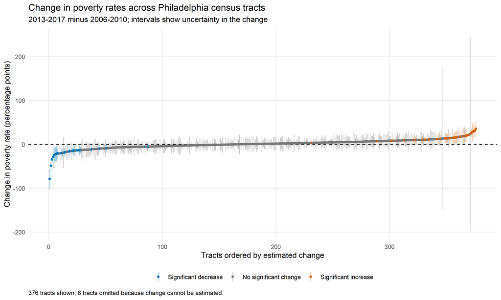

Figure 1: Philadelphia tract poverty-rate changes, 2006–2010 to 2013–2017. Points show estimated changes; vertical lines show 90% confidence intervals for those changes. Tracts are ordered by estimated change, not geographic location.

```r
change_plot_data <- poverty_wide %>%
  filter(is.finite(change_pp), is.finite(change_moe)) %>%
  arrange(change_pp, GEOID) %>%
  mutate(tract_rank = row_number())

ggplot(change_plot_data,
       aes(x = tract_rank, y = change_pp, color = change_result)) +
  geom_linerange(aes(ymin = change_lower_90, ymax = change_upper_90),
                 linewidth = 0.35, alpha = 0.55) +
  geom_hline(yintercept = 0, linetype = "dashed", color = "black") +
  geom_point(size = 1.2) +
  scale_color_manual(
    values = c("Significant decrease" = "#0072B2",
               "No significant change" = "#777777",
               "Significant increase" = "#D55E00"),
    breaks = c("Significant decrease", "No significant change",
               "Significant increase"),
    drop = FALSE
  ) +
  labs(
    title = "Change in poverty rates across Philadelphia census tracts",
    subtitle = "2013-2017 minus 2006-2010; intervals show uncertainty in the change",
    x = "Tracts ordered by estimated change",
    y = "Change in poverty rate (percentage points)",
    color = NULL,
    caption = paste(nrow(change_plot_data), "tracts shown;",
                    nrow(poverty_wide) - nrow(change_plot_data),
                    "tracts omitted because change cannot be estimated.")
  ) +
  theme_minimal(base_size = 11) +
  theme(legend.position = "bottom", panel.grid.minor = element_blank(),
        plot.caption = element_text(hjust = 0))
```

**Results.** Of 384 census tracts across the two periods, 36 show a significant increase and 27 show a significant decrease at the 90% level. There are 313 tracts with no statistically detectable change and 8 without sufficient data. These counts describe how many areas experienced detectable changes. Because tracts have different populations, the counts alone do not show whether Philadelphia’s overall poverty rate increased or decreased.